# Why My Predicted and Raw Data Plots Look the Same

2025-10-08

```r
data_elk<-read.csv("../data/elk_example.csv")
```

When you fit a linear model and compare a predicted plot from `sjPlot::plot_model()` with a raw data scatterplot, you might notice that they look nearly identical — same cloud of points, same regression line.

This document explains why that happens, using your model as an example:

```r
top_model <- lm(formula = density ~ distance + elev, data = data_elk)
```

## 1. Simple Linear Model Effects

Your model includes two continuous predictors:

`density` ~ `distance` + `elev`

When you plot:

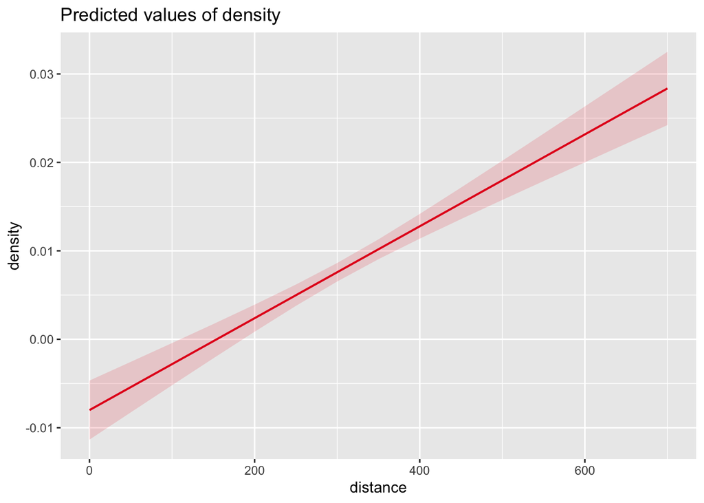

```r
plot_model(top_model, type = "pred", terms = "distance")
```

sjPlot:

- Holds the other variable (elev) constant at its mean value.
- Predicts density across the range of distance.

If both predictors are not strongly correlated, the line representing the partial effect of `distance` will look almost identical to the raw regression line of `density` ~ `distance`.

## 2. Why They Look the Same

If your model is simple and the predictors are roughly independent:

The partial slope (controlling for other predictors) ≈ the marginal slope (simple regression of `density` ~ `distance`).

Hence, both plots appear visually identical.

You can verify this directly (correlation check):

```r
cor(data_elk$distance, data_elk$elev, use = "complete.obs")
```

```
## [1] -0.1397799
```

If the correlation is near 0, the partial and simple relationships align perfectly.

## 3. Conceptual Difference

Even if the plots look the same, their meanings differ:

| **Plot Type** | **What It Shows** | **Interpretation** |
| --- | --- | --- |
| **Raw scatter + `lm` line** | Relationship between `distance` and `density` ignoring `elev` | Marginal effect |
| **Predicted (`plot_model`)** | Relationship between `distance` and `density` holding `elev` constant | Partial effect |

## 4. Seeing the Difference More Clearly

If you visualize both predictors, you can compare their effects side-by-side.

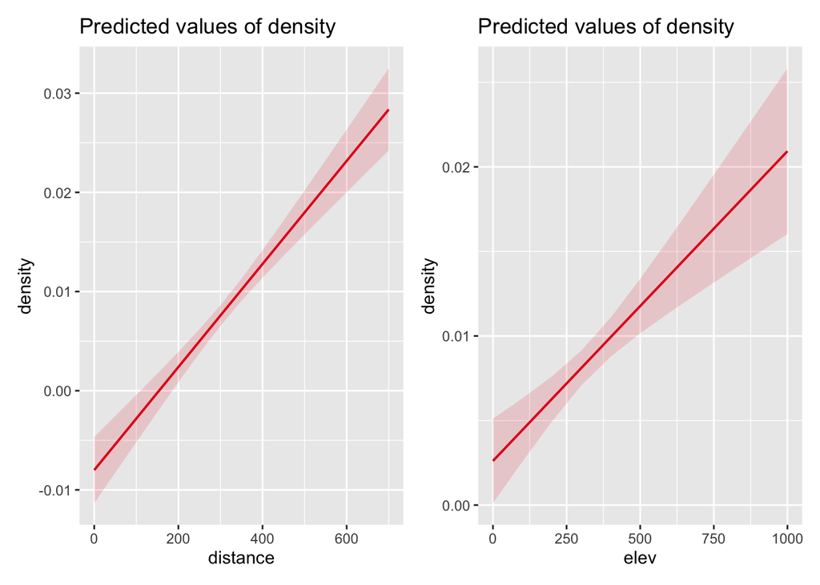

```r
p1 <- plot_model(top_model, type = "pred", terms = "distance")
p2 <- plot_model(top_model, type = "pred", terms = "elev")

p1 + p2 + plot_layout(ncol = 2)
```

Compare those with the raw data plots:

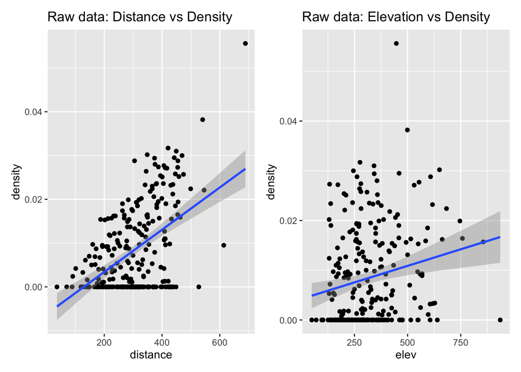

```r
p_raw1 <- ggplot(data_elk, aes(distance, density)) +
  geom_point() +
  geom_smooth(method = "lm", se = TRUE) +
  labs(title = "Raw data: Distance vs Density")

p_raw2 <- ggplot(data_elk, aes(elev, density)) +
  geom_point() +
  geom_smooth(method = "lm", se = TRUE) +
  labs(title = "Raw data: Elevation vs Density")

p_raw1 + p_raw2 + plot_layout(ncol = 2)
```

If one line differs between panels, that predictor is correlated with the other — and the partial effect diverges from the marginal one.

## 5. Making the Difference Explicit

You can compute partial predictions manually. Here, we predict `density` across the range of `distance`, holding `elev` at its mean:

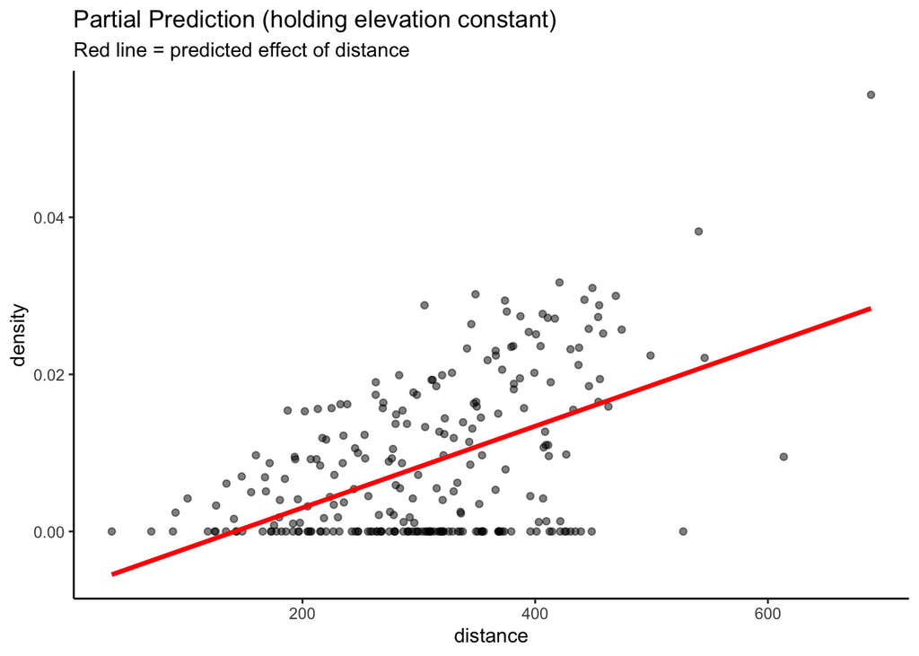

```r
newdata <- data.frame(
  distance = seq(min(data_elk$distance), max(data_elk$distance), length.out = 100),
  elev = mean(data_elk$elev, na.rm = TRUE)
)

newdata$pred <- predict(top_model, newdata)

ggplot(data_elk, aes(distance, density)) +
  geom_point(alpha = 0.5) +
  geom_line(data = newdata, aes(distance, pred), color = "red", linewidth = 1.2) +
  theme_classic() +
  labs(title = "Partial Prediction (holding elevation constant)",
       subtitle = "Red line = predicted effect of distance")
```

That red line is exactly what `plot_model(type = "pred")` displays.

## 6. Summary

Your predicted plots look like your raw data plots because your model is simple and linear — the partial effect of distance controlling for `elev` is nearly identical to the simple regression of `density` ~ `distance`.

## 7. Optional Extension: When They Differ

When predictors are strongly correlated or interact, the predicted plot will differ from the raw scatter. You can explore this by adding a simulated interaction:

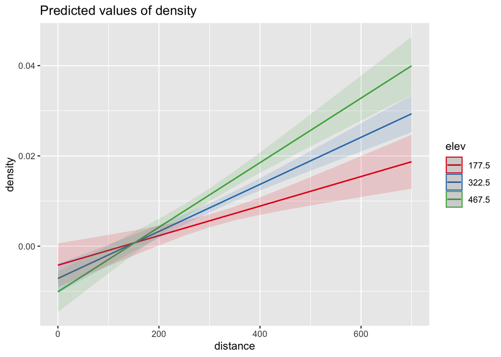

```r
# Example of divergence
data_elk$interaction <- data_elk$distance * data_elk$elev
mod_int <- lm(density ~ distance * elev, data = data_elk)
plot_model(mod_int, type = "pred", terms = c("distance", "elev"))
```

In such cases, the “partial” relationship changes shape depending on the covariate’s level.

References

- Fox, J. (2016). Applied Regression Analysis and Generalized Linear Models (3rd ed.). Sage.
- Hector, A. (2015). The New Statistics with R: An Introduction for Biologists. Oxford University Press.
- Lüdecke, D., et al. (2021). sjPlot: Data Visualization for Statistics in Social Science.